# Air pollution and mouse brain omics

Detailed methods, original-study reproduction and project analyses

29 October 2026

## Scientific scope and levels of evidence

01 / Context

04

independent exposure studies

- **Question:** which regional expression patterns accompany the original mouse exposure experiments?
- **Reproduction:** recover deposited author results using the same source animals.
- **Project extensions:** new primary contrasts, enrichment, interactions and spatial-reference models.
- **Spatial interpretation:** measured unexposed cells, fitted reference estimates and an illustrative PM₂.₅ scenario remain separately identified.

Scientific references[Rajagopalan et al., JCI 2020](https://doi.org/10.1172/JCI137315) · [Zhang et al., Science 2025](https://doi.org/10.1126/science.adu4132) · [Nakamya et al., IJMS 2025](https://doi.org/10.3390/ijms26062407)

## Brain regions and exposure designs define the question

01 / Context

Regional RNA measurements can identify expression associations under a particular route, dose, genotype and age.

The project addresses three linked questions:

1. Can the deposited author analyses be reconstructed?
2. What do explicitly specified reanalyses and response-interaction tests show?
3. Where are prioritized transcripts detected in an independent measured brain reference?

Scientific references[Rajagopalan et al., JCI 2020](https://doi.org/10.1172/JCI137315) · [Zhang et al., Science 2025](https://doi.org/10.1126/science.adu4132) · [Nakamya et al., IJMS 2025](https://doi.org/10.3390/ijms26062407)

## Two PM₂.₅ RNA-seq studies

01 / Context

| Feature | Hypothalamus | Anterior cingulate cortex |
| --- | --- | --- |
| Deposit | GSE145840 | GSE297423 |
| Primary animals | 4 FA + 3 PM | 4 PBS + 4 PM |
| Model / context | Male C57BL/6J, chow-fed | Humanized hWT α-synuclein, sex unreported |
| Exposure route | Concentrated ambient aerosol inhalation | Repeated intranasal PM suspension |
| Starting material | Seven deposited gene-count files | Eight selected libraries from a 20-library matrix |
| Primary inference | PyDESeq2, PM versus FA | PyDESeq2, PM versus PBS |

Scientific references[Rajagopalan et al., JCI 2020](https://doi.org/10.1172/JCI137315) · [Zhang et al., Science 2025](https://doi.org/10.1126/science.adu4132)

## Hippocampal miRNA and ozone studies

01 / Context

| Feature | PM₂.₅ miRNA | Ozone RNA-seq |
| --- | --- | --- |
| Deposit | GSE93967 | E-MTAB-14917 |
| Sequenced / assayed animals | 9 arrays, 3 per group | 24 animals, 3 in each of 8 strata |
| Design | Saline, 1 or 5 mg/kg PM | 2 ages × 2 APOE genotypes × 2 exposures |
| Assay | Agilent miRNA V19 microarray | Paired-end left-hippocampus RNA-seq |
| Input | Deposited quantile-normalized signal | Original FASTQ pairs |
| Scale | Original signal units | Estimated gene fragments + length offsets |

Scientific references[Ku et al., Part. Fibre Toxicol. 2017](https://doi.org/10.1186/s12989-017-0215-3) · [Nakamya et al., IJMS 2025](https://doi.org/10.3390/ijms26062407)

## Experimental units and analytical populations

01 / Context

01

unexposed spatial donor

- **Bulk and arrays:** the sequenced or assayed animal is the biological replicate.
- **Author reproduction:** the same deposited animals supply computational agreement.
- **Spatial reference:** 52,393 ACA/HY cells come from one unexposed donor.
- **Spatial validation:** reserving sections measures within-donor prediction.

No pooled pollutant dose, cross-study effect or independent-cell exposure test is estimated.

Scientific references[Rajagopalan et al., JCI 2020](https://doi.org/10.1172/JCI137315) · [Zhang et al., Science 2025](https://doi.org/10.1126/science.adu4132) · [Nakamya et al., IJMS 2025](https://doi.org/10.3390/ijms26062407)

## Bulk contrasts and spatial cells answer different questions

01 / Context

**Exposure comparison.** Bulk RNA-seq combines RNA from many cells in each sampled region. The animal supplies the independent replicate. A regional difference can reflect expression within cells, changes in cellular composition, or both.

**Spatial reference.** MERFISH counts a targeted gene panel at measured cell positions in one unexposed donor. It shows where a transcript is detected in that reference.

**Connection.** We map regional candidates onto the measured panel. The atlas supplies anatomical context, while the separate exposure experiment supplies the regional contrast.

Scientific references[Rajagopalan et al., JCI 2020](https://doi.org/10.1172/JCI137315) · [Zhang et al., Science 2025](https://doi.org/10.1126/science.adu4132) · [Zhang et al., Nature 2023](https://doi.org/10.1038/s41586-023-06808-9)

## Project workflow and provenance

01 / Context

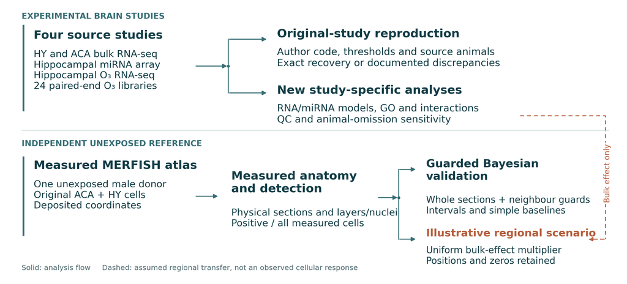

Follow the upper branch from exposure data to author reproduction and new study-specific analyses. The lower branch starts with an independent, unexposed MERFISH donor. Its measured anatomy supports reference modeling. The dashed regional bulk-effect transfer enters only the illustrative scenario, so the diagram does not imply measured cellular exposure responses.

Interactive hypothalamus slide · Interactive cortex slide

Analysis: this project[Rajagopalan et al., JCI 2020](https://doi.org/10.1172/JCI137315) · [Zhang et al., Science 2025](https://doi.org/10.1126/science.adu4132) · [Nakamya et al., IJMS 2025](https://doi.org/10.3390/ijms26062407)

## Fosb across the experimental and spatial analyses

01 / Context

**Regional evidence.** The eight-animal ACA comparison estimates higher Fosb RNA after PM exposure. Its shrunken log₂ fold change is +0.99711, corresponding to a 1.996-fold multiplier.

**Measured reference.** The separate atlas detects Fosb in 1,418 of 14,582 ACA cells. Original coordinates place these detections within the registered anatomy.

**Illustrative display.** Multiplying every reference value by 1.996 changes the color and magnitude while preserving positions and measured zeros. This assumption illustrates the regional estimate without identifying the cells that actually respond to PM.

Scientific references[Zhang et al., Science 2025](https://doi.org/10.1126/science.adu4132) · [Zhang et al., Nature 2023](https://doi.org/10.1038/s41586-023-06808-9) · [Love et al., Genome Biol. 2014](https://doi.org/10.1186/s13059-014-0550-8)

## Methods

02 / Methods

Original-study reconstruction, new statistical analyses and measured spatial reference

## Criteria for computational reproduction

02 / Methods

| Layer | Comparison | Interpretation |
| --- | --- | --- |
| Inputs | Identifiers, counts, samples and source hashes | Verify the same analytical starting point |
| Model | Design, normalization, filter and multiplicity family | Reconstruct the stated procedure |
| Outputs | Feature identities, effects, p values and selected sets | Counts alone are insufficient |
| Missing specification | Unrecovered parameters and altered quantification | Report sensitivity or concordance explicitly |

Scientific references[Rajagopalan et al., JCI 2020](https://doi.org/10.1172/JCI137315) · [Zhang et al., Science 2025](https://doi.org/10.1126/science.adu4132) · [Nakamya et al., IJMS 2025](https://doi.org/10.3390/ijms26062407)

## Numerical recovery and independent biological validation

02 / Methods

**Numerical recovery** asks whether the same deposited inputs and analysis rules recover the authors’ effects, probabilities and selected genes. Cortex recovers all four tested significant-gene sets exactly.

**Methodological sensitivity** asks what changes when a model, filter or analytical population changes. Hypothalamic reconstruction remains incomplete because key RUVg specifications are unavailable.

**Independent biological validation** would require additional animals or experiments. Reanalyzing the source animals, even with another software package, checks computation and assumptions while leaving the biological sample size unchanged.

Scientific references[Zhang et al., Science 2025](https://doi.org/10.1126/science.adu4132) · [Rajagopalan et al., JCI 2020](https://doi.org/10.1172/JCI137315)

## Cortex author-aligned count analysis

02 / Methods

1. Match the original Zenodo count matrix to the GEO deposit.
2. Retain all **20 libraries in five treatment groups**.
3. Keep genes with ≥10 counts in ≥4 libraries: **21,388 genes**.
4. Reconstruct R DESeq2 with design `~group`.
5. Preserve default independent-filtering α = 0.1, then select **BH q < 0.05**.
6. Reconstruct the code-defined PCA using TMM log₂CPM, top 500 variable genes and variance scaling.

Scientific references[Zhang et al., Science 2025](https://doi.org/10.1126/science.adu4132)

## Hypothalamic RUVg specification remains incomplete

02 / Methods

The paper describes lane normalization, empirical controls and RUVg before downstream testing.

- The exact **5,000 negative-control genes** and unwanted-factor count **k** are unavailable.
- A declared sensitivity uses all 11 FA/PM/HFD libraries with TMM/voom and limma, **without invented RUVg factors**.
- Shared source universe: 50,417 features. Exclude 91 HFD-only rows rather than invent zeros.
- GENCODE M13 coding filter + CPM filter yields 13,398 tested genes.

Scientific references[Rajagopalan et al., JCI 2020](https://doi.org/10.1172/JCI137315)

## miRNA target reconstruction and testing gates

02 / Methods

- Recover the prespecified Figure 6 target **mmu-miR-574-5p**.
- Preserve all nine arrays and the original normalized signal.
- Reconstruct ANOVA and pooled-MSE LSD pairwise comparisons.
- Distinguish an **unprotected pairwise test** from a **protected LSD procedure requiring omnibus significance**.
- Compare the target with the new moderated limma analysis and its array-wide BH family.

Scientific references[Ku et al., Part. Fibre Toxicol. 2017](https://doi.org/10.1186/s12989-017-0215-3) · [Ritchie et al., NAR 2015](https://doi.org/10.1093/nar/gkv007)

## Ozone table reconstruction and cross-pipeline comparison

02 / Methods

**Exact selection reconstruction**

The deposited E4/E3 table contains genotype effects. Apply its nominal p < 0.05 and |log₂FC| > 0.3 rule.

**Conditional effect concordance**

Compare exact-symbol finite effects from the new Salmon/tximport counts with published results. Reestimate candidate-model dispersions under their declared designs.

The original HISAT2/featureCounts pipeline, historical annotation and complete testing specification are not fully reconstructed.

Scientific references[Nakamya et al., IJMS 2025](https://doi.org/10.3390/ijms26062407)

## Negative-binomial model for RNA counts

02 / Methods

$$K_{gi}\sim\mathrm{NB}(\mu_{gi},\alpha_g),\qquad
\operatorname{Var}(K_{gi})=\mu_{gi}+\alpha_g\mu_{gi}^{2}$$

$$\log\mu_{gi}=\log o_{gi}+\mathbf x_i^\top\boldsymbol\beta_g$$

- $K_{gi}$: assigned counts or rounded estimated fragments.
- $\alpha_g$: gene-specific dispersion, estimated with shrinkage.
- $o_{gi}$: normalization factor. Ozone additionally carries effective-length information.
- The design matrix defines the comparison before the test.

Scientific references[Love et al., Genome Biol. 2014](https://doi.org/10.1186/s13059-014-0550-8) · [Muzellec et al. 2023](https://doi.org/10.1093/bioinformatics/btad547)

## Normalization and dispersion in the count model

02 / Methods

**Normalization** accounts for technical differences in the amount of RNA sequenced. Otherwise, a deeply sequenced library could appear higher for many genes even without a biological change. Ozone also uses effective-length information from transcript quantification.

**Dispersion** describes variation among animals beyond ordinary count noise. A variable gene needs a larger, more consistent group difference to supply strong evidence.

**The coefficient** estimates the chosen regional comparison after these adjustments. Neither normalization nor dispersion estimation creates biological replicates or removes an unmeasured source of confounding.

Scientific references[Love et al., Genome Biol. 2014](https://doi.org/10.1186/s13059-014-0550-8) · [Muzellec et al. 2023](https://doi.org/10.1093/bioinformatics/btad547) · [Soneson et al. 2015](https://doi.org/10.12688/f1000research.7563.2)

## Count filtering and normalization populations

02 / Methods

| Analysis | Count filter | Retained genes | Fitted samples |
| --- | --- | --- | --- |
| HY primary | ≥10 in ≥3 | 19,611 | 7 |
| ACA primary | ≥10 in ≥4 | 19,235 | 8 |
| ACA author reconstruction | ≥10 in ≥4 | 21,388 | 20 |
| O₃ primary | ≥10 in ≥3 | 18,537 | 24 |

PM primary analyses use median-of-ratios size factors. Different fitted sample populations change the filter and dispersion estimates.

Scientific references[Rajagopalan et al., JCI 2020](https://doi.org/10.1172/JCI137315) · [Zhang et al., Science 2025](https://doi.org/10.1126/science.adu4132) · [Nakamya et al., IJMS 2025](https://doi.org/10.3390/ijms26062407)

## Wald evidence, shrinkage and multiple testing

02 / Methods

$$z_g=\frac{\widehat\beta_g}{\operatorname{SE}(\widehat\beta_g)},
\qquad \mathrm{CI}_{95\%}=\widehat\beta_g\pm1.959964\,\operatorname{SE}(\widehat\beta_g)$$

$$q_{(i)}=\min\!\left(1,\min_{j\ge i}\frac{m\,p_{(j)}}{j}\right)$$

- Original MLEs, SEs and p values define the Wald/BH evidence.
- apeglm-style shrunken effects support visualization and ranking stability.
- Pointwise intervals are not simultaneous or selection-adjusted.
- Each declared test family has its own multiplicity correction.

Scientific references[Love et al., Genome Biol. 2014](https://doi.org/10.1186/s13059-014-0550-8) · [Zhu et al. 2019](https://doi.org/10.1093/bioinformatics/bty895) · [Rajagopalan et al., JCI 2020](https://doi.org/10.1172/JCI137315)

## Effect size, uncertainty and the discovery threshold

02 / Methods

**Effect size** describes direction and magnitude. A log₂ fold change of +1 corresponds to twice the regional RNA level, while −1 corresponds to half, under the fitted contrast.

**The standard error and Wald test** compare the estimated effect with its sampling uncertainty. A large fold change from inconsistent animals may have weak evidence.

**BH adjustment** evaluates many genes as a declared testing family. A nominal p < 0.05 can become q ≥ 0.05. Shrinkage stabilizes displayed effect estimates, while the stated inferential model determines the reported tests.

Scientific references[Love et al., Genome Biol. 2014](https://doi.org/10.1186/s13059-014-0550-8) · [Zhu et al. 2019](https://doi.org/10.1093/bioinformatics/bty895)

## Quality control and animal sensitivity

02 / Methods

- For RNA-count inputs, verify nonnegative integers, exact IDs and sample assignments.
- Inspect library size, normalization, PCA and sample correlations.
- Preserve Cook-filtered inference and convergence flags.
- Retain all originally selected animals. PCA separation alone does not justify exclusion.
- Refit the HY primary model leaving one animal out at a time.
- Compare the fixed HY hypothesis across Python and R implementations.

Scientific references[Rajagopalan et al., JCI 2020](https://doi.org/10.1172/JCI137315) · [Zhang et al., Science 2025](https://doi.org/10.1126/science.adu4132) · [Love et al., Genome Biol. 2014](https://doi.org/10.1186/s13059-014-0550-8)

## Linear modeling of deposited miRNA signals

02 / Methods

$$y_{fi}=\mathbf x_i^\top\boldsymbol\beta_f+\epsilon_{fi},
\qquad \Delta_f=\beta_{f,\mathrm{PM}}-\beta_{f,\mathrm{Control}}$$

- 1,268 input rows → 21 controls/unannotated + 2 unusable rows excluded → **1,245 tested features**.
- limma design `~0+condition`, two pairwise contrasts and a separate omnibus moderated F test.
- Empirical Bayes: trend = TRUE, robust = FALSE.
- Keep 823 low-detection flags and negative signal values.
- Effects remain **mean differences in deposited signal units**.

Scientific references[Ku et al., Part. Fibre Toxicol. 2017](https://doi.org/10.1186/s12989-017-0215-3) · [Ritchie et al., NAR 2015](https://doi.org/10.1093/nar/gkv007)

## Ozone processing begins with all original reads

02 / Methods

1. Match 24 biological SourceNames to paired FASTQ runs and eight strata.
2. Inspect the first 200,000 read pairs per library with fastp.
3. Apply consistent adapter trimming to full libraries.
4. Retain full before/after QC. Disable quality, length, poly-G and duplicate filtering.
5. Process **532,781,354 paired fragments** across all 24 libraries.

Sampled Q30: 92.37–96.49%. All sequenced animals remain in the analysis.

Scientific references[Nakamya et al., IJMS 2025](https://doi.org/10.3390/ijms26062407)

## Selective alignment and effective-length offsets

02 / Methods

**Salmon 2.5.1**

GENCODE M25 transcriptome + whole GRCm38 primary-genome decoys. Automatic library type, sequence and GC bias models.

**tximport**

Estimated fragments and sample-specific abundance-weighted effective gene lengths. `countsFromAbundance = “no”`.

**DESeqDataSetFromTximport**

Gene/sample length normalization offsets enter inference. Mapping ranges from **72.31% to 88.33%**.

Scientific references[Patro et al. 2017](https://doi.org/10.1038/nmeth.4197) · [Soneson et al. 2015](https://doi.org/10.12688/f1000research.7563.2) · [Nakamya et al., IJMS 2025](https://doi.org/10.3390/ijms26062407)

## Eight-parameter ozone factorial model

02 / Methods

$$\log\mu=\log o+\beta_0+\beta_A A+\beta_G G+\beta_E E
+\beta_{AG}AG+\beta_{AE}AE+\beta_{GE}GE+\beta_{AGE}AGE$$

Define $A=1$ for 17-month onset, $G=1$ for APOE4 and $E=1$ for O₃.

- Full design: age × genotype × exposure.
- 24 animals, 3 in each of 8 strata. Design rank = 8.
- 18,537 retained genes.
- Fixed prefilter, Cook checks and validity masks. Adaptive independent filtering is disabled.

Scientific references[Nakamya et al., IJMS 2025](https://doi.org/10.3390/ijms26062407) · [Love et al., Genome Biol. 2014](https://doi.org/10.1186/s13059-014-0550-8)

## Stratum effects and covariance-aware differences

02 / Methods

$$\widehat\Delta=\mathbf c^\top\widehat{\boldsymbol\beta},
\qquad \operatorname{SE}(\widehat\Delta)
=\sqrt{\mathbf c^\top\widehat V\mathbf c}$$

| O₃ versus FA effect | Linear combination |
| --- | --- |
| 3M / E3 | $\beta_E$ |
| 3M / E4 | $\beta_E+\beta_{GE}$ |
| 17M / E3 | $\beta_E+\beta_{AE}$ |
| 17M / E4 | $\beta_E+\beta_{AE}+\beta_{GE}+\beta_{AGE}$ |

A difference between response effects requires its own contrast.

Scientific references[Nakamya et al., IJMS 2025](https://doi.org/10.3390/ijms26062407) · [Love et al., Genome Biol. 2014](https://doi.org/10.1186/s13059-014-0550-8)

## Global exposure and response-heterogeneity tests

02 / Methods

$$D=2(\ell_{\mathrm{full}}-\ell_{\mathrm{reduced}})
\ \overset{H_0}{\approx}\ \chi^2_{\Delta df}$$

| Test | Removed terms under the null | df |
| --- | --- | --- |
| Any exposure effect | E, AE, GE, AGE | 4 |
| Genotype-dependent exposure | GE, AGE | 2 |
| Age-dependent exposure | AE, AGE | 2 |
| Three-way interaction | AGE | 1 |

Separate BH families are reported, plus supplementary pooled-family corrections.

Scientific references[Nakamya et al., IJMS 2025](https://doi.org/10.3390/ijms26062407) · [Love et al., Genome Biol. 2014](https://doi.org/10.1186/s13059-014-0550-8)

## Interaction tests compare exposure effects directly

02 / Methods

**Within a stratum**, the model compares ozone with filtered air at one starting age and APOE genotype. Each stratum has only three animals per exposure group.

**An interaction** asks whether the ozone effect itself differs between ages or genotypes, using coefficient differences and their covariance. One significant stratum and one nonsignificant stratum do not answer that question.

**Here**, the joint age-dependent exposure LRT identifies eight genes under its own BH family, and one under BH pooled across the three joint heterogeneity tests. The conclusion depends on the stated test and family.

Scientific references[Nakamya et al., IJMS 2025](https://doi.org/10.3390/ijms26062407) · [Love et al., Genome Biol. 2014](https://doi.org/10.1186/s13059-014-0550-8)

## GO over-representation uses a testable universe

02 / Methods

$$P(X\ge k)=\sum_{x=k}^{\min(K,n)}
\frac{\binom Kx\binom{N-K}{n-x}}{\binom Nn}$$

- $N$: unique mapped genes with finite adjusted DE p values.
- $n$: BH-significant foreground, up/down separately by MLE sign.
- $K$: GO-BP term members in that universe; $k$: overlap.
- Test 15–500-member terms. Keep zero-overlap terms at p = 1.
- BH across all eligible terms within each contrast/direction family.

Scientific references[Subramanian et al., PNAS 2005](https://doi.org/10.1073/pnas.0506580102) · [Gene Ontology Consortium](https://geneontology.org/docs/go-enrichment-analysis/)

## Ranked enrichment preserves weak coordinated signals

02 / Methods

$$RS(t)=
\frac{\sum_{j\le t,\ j\in S}|r_j|}{\sum_{j\in S}|r_j|}
-\frac{\#\{j\le t:j\notin S\}}{N-|S|}$$

- Rank $r_j$: unshrunken Wald statistic with finite original p value.
- No gene-level BH or effect-size preselection.
- GSEApy prerank, weight 1, 1,000 gene-set permutations, fixed seed.
- NES and **algorithmic GSEA FDR** differ from ORA/BH.
- Shared genes and GO ancestry make enriched terms correlated.

Scientific references[Subramanian et al., PNAS 2005](https://doi.org/10.1073/pnas.0506580102) · [Gene Ontology Consortium](https://geneontology.org/docs/go-enrichment-analysis/)

## ORA and GSEA use different evidence from the same contrast

02 / Methods

**ORA** starts with genes passing a declared discovery gate and asks whether an annotation contains more selected genes than expected from the tested background. Its answer depends on the foreground and universe.

**GSEA** uses the signed gene ranking and can detect coordinated shifts even when few individual genes pass BH. The analysis uses the frozen ranked-test procedure and algorithmic FDR.

**Interpretation** concerns enrichment of annotated genes. A positive score follows the positive rank direction, while shared genes make related GO terms correlated. RNA enrichment alone does not measure pathway activity.

Scientific references[Gene Ontology Consortium](https://geneontology.org/docs/go-enrichment-analysis/) · [Subramanian et al., PNAS 2005](https://doi.org/10.1073/pnas.0506580102)

## A measured spatial reference from one donor

02 / Methods

| Reference feature | ACA | HY |
| --- | --- | --- |
| Measured cells | 14,582 | 37,811 |
| Physical sections | 18 | 20 |
| Cell classes | 16 | 26 |
| Anatomical subdivisions | 10 | 49 |
| Occupied 100 µm bins | 1,656 | 3,772 |

Zhuang-ABCA-2: one unexposed adult male, one registered hemisphere, **1,122 measured MERFISH genes**.

Scientific references[Zhang et al., Nature 2023](https://doi.org/10.1038/s41586-023-06808-9)

## Deposited section coordinates and registered anatomy

02 / Methods

**Within-section maps**

Deposited experimental x/y after source tissue rotation/alignment. Experimental z estimates acquisition AP.

**3D anatomy and Gaussian basis**

Registered CCF AP/DV/ML in millimeters. The 3D display uses ML, AP and −DV.

Nominal coronal spacing is about 200 µm. Surface mesh steps of 50–150 µm describe rendering, not expression acquisition.

Scientific references[Zhang et al., Nature 2023](https://doi.org/10.1038/s41586-023-06808-9)

## The measured regions in the 3D brain reference

02 / Methods

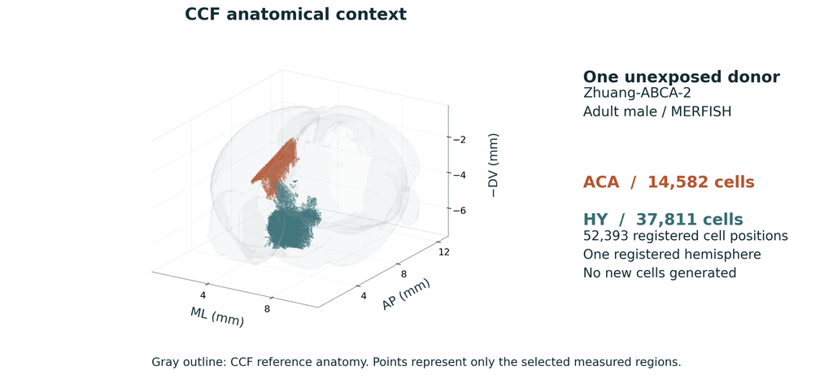

The gray whole-brain surface supplies anatomical context. Rust marks 14,582 ACA cells and teal marks 37,811 HY cells at their registered CCF positions. These 52,393 cells come from one unexposed donor and one registered hemisphere. The reference locates measured cells without filling unsampled regions or mirroring cells into the opposite hemisphere.

Interactive hypothalamus slide · Interactive cortex slide

Analysis: this project[Zhang et al., Nature 2023](https://doi.org/10.1038/s41586-023-06808-9) · [Allen CCF, 2020 annotation](https://alleninstitute.github.io/abc_atlas_access/descriptions/Allen-CCF-2020.html)

## Gene priorities and measured-panel coverage

02 / Methods

1. Preserve the original primary regional BH q and effect estimates.
2. Rank candidates by q, then source symbol or exact ID.
3. Map HY by exact source symbol and ACA by exact Ensembl ID.
4. Annotate products and functions with frozen official NCBI/UniProt records.

**Panel coverage:** 1 of 11 HY primary hits and 76 of 1,167 ACA primary hits are physically measured.

The HY displayed top ten include nine exploratory candidates. All ten ACA candidates satisfy primary BH q < 0.05.

Scientific references[Zhang et al., Nature 2023](https://doi.org/10.1038/s41586-023-06808-9) · [Rajagopalan et al., JCI 2020](https://doi.org/10.1172/JCI137315) · [Zhang et al., Science 2025](https://doi.org/10.1126/science.adu4132)

## Detection fractions retain measured zeros

02 / Methods

$$d_{ig}=\mathbf1(c_{ig}>0),\qquad
\widehat f_{gA}=\frac{\sum_{i\in A}d_{ig}}{n_A}$$

$$b_x=\lfloor x/0.1\rfloor,\qquad b_y=\lfloor y/0.1\rfloor$$

- $A$: selected physical section, anatomy, cell class or occupied bin.
- The denominator includes every selected measured cell, including zeros.
- Bins are 0.1 × 0.1 mm and remain separate by physical section.
- Empty bins are unobserved. No spatial interpolation or density claim is added.

Scientific references[Zhang et al., Nature 2023](https://doi.org/10.1038/s41586-023-06808-9)

## Uniform regional PM₂.₅ scenario

02 / Methods

$$E_{\mathrm{scenario}}(c,g)
=E_{\mathrm{reference}}(c,g)\,
2^{\widehat\beta^{\,\mathrm{shrunk}}_g}$$

| Example | Regional shrunken log₂FC | Multiplier |
| --- | --- | --- |
| HY / Tll1 | −1.22405 | 0.42808 |
| ACA / Fosb | +0.99711 | 1.99600 |

Cell positions and numbers remain fixed. Shared per-gene color limits support comparison.

This is an illustrative propagation of a regional effect into an unexposed reference.

Scientific references[Zhang et al., Nature 2023](https://doi.org/10.1038/s41586-023-06808-9)

## The assumption behind the reference–PM comparison

02 / Methods

**Measured input.** Each cell has its original coordinate and reference expression value. These measurements come from an unexposed animal.

**Scenario rule.** Apply one gene-specific regional multiplier to all reference values. Fosb receives approximately ×2 in ACA. Tll1 receives ×0.428 in HY. Measured zeros stay zero and no cells move, appear or disappear.

**Scientific meaning.** This makes a regional estimate visible in anatomical space. Many cellular response patterns could produce the same bulk effect, so the rule cannot recover cell-specific pollution responses or add spatial resolution.

Scientific references[Zhang et al., Science 2025](https://doi.org/10.1126/science.adu4132) · [Rajagopalan et al., JCI 2020](https://doi.org/10.1172/JCI137315) · [Zhang et al., Nature 2023](https://doi.org/10.1038/s41586-023-06808-9)

## Gaussian baseline with fixed spatial basis functions

02 / Methods

$$y_{ig}=\ln(1+c_{ig})
=\mathbf x_i^\top\boldsymbol\beta_g+\epsilon_{ig}$$

$$\phi_j(\mathbf r)=
\exp\!\left[-\frac12\sum_k\frac{(r_k-m_{jk})^2}{\ell_k^2}\right],
\qquad\boldsymbol\ell=(0.60,0.45,0.45)\ \mathrm{mm}$$

Features: intercept, anatomical indicators, three standardized CCF coordinates, 36 anisotropic RBFs and section nuisance intercepts.

No expression-derived cell-class predictors enter the fit.

Scientific references[Zhang et al., Nature 2023](https://doi.org/10.1038/s41586-023-06808-9) · [Murphy, 2007, Gaussian conjugacy](https://www.cs.ubc.ca/~murphyk/Papers/bayesGauss.pdf) · [Rasmussen & Williams, 2006, ch. 2](https://gaussianprocess.org/gpml/chapters/RW2.pdf)

## Proper priors and analytical posterior

02 / Methods

$$\boldsymbol\beta\mid\sigma^2\sim
\mathcal N(0,\sigma^2V_0),\qquad \sigma^2\sim IG(3,1)$$

$$V_n=(X^\top X+V_0^{-1})^{-1},\quad
m_n=V_nX^\top y,\quad a_n=3+n/2$$

$$b_n=1+\frac12\left(y^\top y-m_n^\top V_n^{-1}m_n\right)$$

Prior variance multipliers: intercept 25, anatomy 1, linear coordinates 0.25, each RBF 1/36, each section 0.25.

Cholesky computation checks the normal equations and posterior scale.

Scientific references[Zhang et al., Nature 2023](https://doi.org/10.1038/s41586-023-06808-9) · [Murphy, 2007, Gaussian conjugacy](https://www.cs.ubc.ca/~murphyk/Papers/bayesGauss.pdf) · [Rasmussen & Williams, 2006, ch. 2](https://gaussianprocess.org/gpml/chapters/RW2.pdf)

## How the prior and reference measurements form a posterior

02 / Methods

**Before the observations**, a proper prior constrains coefficient magnitudes and unexplained variation. It regularizes sparse anatomical groups and spatial basis functions without supplying new measurements.

**The likelihood** describes how measured reference expression would vary for a given coefficient set. Combining it with the prior gives a posterior distribution of plausible reference parameters.

**Prediction** then propagates that distribution to a defined target. A smooth posterior mean is only a conditional estimate. Its scientific usefulness still requires held-out comparisons, interval checks and sensitivity to the stated assumptions.

Scientific references[Murphy, 2007, Gaussian conjugacy](https://www.cs.ubc.ca/~murphyk/Papers/bayesGauss.pdf) · [Rasmussen & Williams, 2006, ch. 2](https://gaussianprocess.org/gpml/chapters/RW2.pdf) · [SciPy, beta-binomial distribution](https://docs.scipy.org/doc/scipy/reference/generated/scipy.stats.betabinom.html)

## Credible and new-section predictive intervals

02 / Methods

**Section-adjusted latent mean**

$$f_*\mid y\sim t_{2a_n}\left(x_*^\top m_n,\
\sqrt{\frac{b_n}{a_n}x_*^\top V_nx_*}\right)$$

**New cell in a new physical section**

$$y_*\mid y\sim t_{2a_n}\left(x_*^\top m_n,\
\sqrt{\frac{b_n}{a_n}\left(1.25+x_*^\top V_nx_*\right)}\right)$$

The second arguments are **Student-t scales**, not variances.

Maps show the full-reference fit at measured locations. Held-out prediction is evaluated separately.

Scientific references[Zhang et al., Nature 2023](https://doi.org/10.1038/s41586-023-06808-9) · [Murphy, 2007, Gaussian conjugacy](https://www.cs.ubc.ca/~murphyk/Papers/bayesGauss.pdf) · [Rasmussen & Williams, 2006, ch. 2](https://gaussianprocess.org/gpml/chapters/RW2.pdf)

## Whole-section validation with neighboring guards

02 / Methods

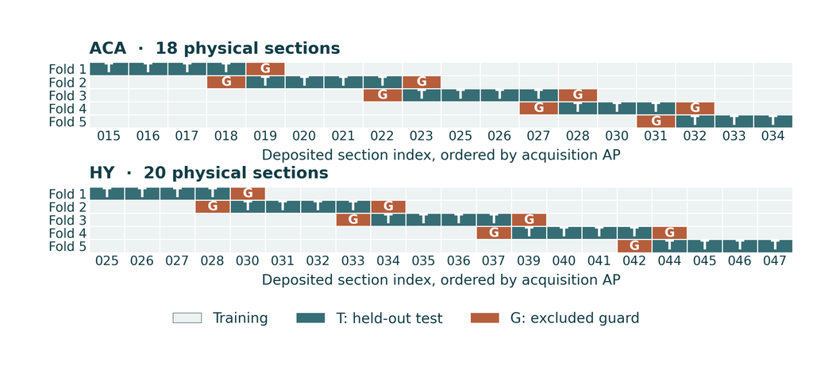

Each row marks one validation fold along the ordered physical sections. Teal sections supply the held-out test, rust sections are excluded neighbors, and pale sections train the model. Every measured cell is tested once. Reserving whole sections reduces local leakage, while all folds still describe the same donor.

Analysis: this project[Zhang et al., Nature 2023](https://doi.org/10.1038/s41586-023-06808-9)

## Why validation reserves sections and their neighbors

02 / Methods

**The prediction question** is how the model performs at a physical section it has not seen. Randomly splitting nearby cells could leave very similar local information in training and testing.

**The guard** removes the represented sections adjacent to the test block from training. Feature standardization, anatomical vocabularies and spatial basis preparation use the remaining training data only.

**The comparison** uses identical folds for spatial and simpler baseline models. Better fit to the complete atlas cannot replace better held-out prediction. These folds assess transfer within one donor, while cross-donor and exposure transfer remain untested.

Scientific references[Zhang et al., Nature 2023](https://doi.org/10.1038/s41586-023-06808-9) · [Murphy, 2007, Gaussian conjugacy](https://www.cs.ubc.ca/~murphyk/Papers/bayesGauss.pdf) · [SciPy, beta-binomial distribution](https://docs.scipy.org/doc/scipy/reference/generated/scipy.stats.betabinom.html)

## Hierarchical model of bounded detection probability

02 / Methods

$$Y_{sag}\mid p_{sag}\sim
\operatorname{Binomial}(n_{sa},p_{sag})$$

$$p_{sag}\mid\mu_{ag},\kappa_{ag}\sim
\operatorname{Beta}(\mu_{ag}\kappa_{ag},(1-\mu_{ag})\kappa_{ag})$$

$$\mu_{ag}\sim\operatorname{Beta}(0.5,0.5),\qquad
\ln\kappa_{ag}\sim\mathcal N(\ln20,1.5^2)$$

Genes/anatomies have separate fits. Section propensities are exchangeable within each fit. Probabilities stay between 0 and 1.

Scientific references[Zhang et al., Nature 2023](https://doi.org/10.1038/s41586-023-06808-9) · [SciPy, beta-binomial distribution](https://docs.scipy.org/doc/scipy/reference/generated/scipy.stats.betabinom.html)

## Finite-grid integration and uncertainty computation

02 / Methods

- Main grid: **64 μ × 48 κ prior quantiles**, equal prior-quantile weights.
- Normalize log beta-binomial likelihood weights with log-sum-exp.
- Hypermean μ intervals: weighted discrete-grid quantiles.
- Known-section p and held-out positive-count intervals: **8,192 seeded mixture draws**.
- Full-reference new-section p intervals: numerical inversion of the weighted Beta-mixture CDF.
- Check 32 × 24 and 96 × 64 grids without selecting a model from test results.

Scientific references[Zhang et al., Nature 2023](https://doi.org/10.1038/s41586-023-06808-9) · [SciPy, beta-binomial distribution](https://docs.scipy.org/doc/scipy/reference/generated/scipy.stats.betabinom.html)

## Three distinct detection uncertainty targets

02 / Methods

| Target | Conditioning | Interval interpretation |
| --- | --- | --- |
| Known-section $p_{sa}$ | Its observed positives and denominator | Credible interval of that fitted section |
| Anatomy mean $\mu_a$ | Exchangeable section information | Credible interval of the hypermean |
| New-section $p_*$ or $Y_*$ | No counts from that new section | Predictive distribution of its propensity or count |

An unseen held-out anatomy stays **prior-only** and remains in evaluation.

A fitted known-section interval is not a held-out prediction.

Scientific references[Zhang et al., Nature 2023](https://doi.org/10.1038/s41586-023-06808-9) · [SciPy, beta-binomial distribution](https://docs.scipy.org/doc/scipy/reference/generated/scipy.stats.betabinom.html)

## Different intervals answer different detection questions

02 / Methods

**A known section:** after observing its positives and all-cell denominator, estimate that section’s underlying detection probability. Its credible interval conditions on those observations.

**An anatomical mean:** combine the exchangeable section information to estimate the typical propensity for that anatomy. This hypermean has its own credible interval.

**A new section:** predict its propensity before seeing its counts, or predict a positive-cell count at a specified denominator. Section heterogeneity and, for counts, sampling variation enter this prediction. Always read the target before comparing interval widths or coverage.

Scientific references[Zhang et al., Nature 2023](https://doi.org/10.1038/s41586-023-06808-9) · [SciPy, beta-binomial distribution](https://docs.scipy.org/doc/scipy/reference/generated/scipy.stats.betabinom.html)

## Prediction metrics and baseline comparisons

02 / Methods

$$\operatorname{RMSE}=
\sqrt{\frac1N\sum_i(y_i-\widehat y_i)^2}$$

$$\operatorname{Brier}=
\frac{\sum_j[Y_j(1-\widehat p_j)^2+
(n_j-Y_j)\widehat p_j^2]}{\sum_j n_j}$$

Gaussian baseline: compare anatomy-only regression and 30-neighbor prediction.

Detection baseline: collapse anatomy within each permitted training section.

Report held-out interval coverage **together with width**. Lower prediction loss is better.

Scientific references[Zhang et al., Nature 2023](https://doi.org/10.1038/s41586-023-06808-9) · [Murphy, 2007, Gaussian conjugacy](https://www.cs.ubc.ca/~murphyk/Papers/bayesGauss.pdf) · [SciPy, beta-binomial distribution](https://docs.scipy.org/doc/scipy/reference/generated/scipy.stats.betabinom.html)

## Results reconstructed from the original studies

03 / Author reproduction

Exact output recovery, partial methodological sensitivity and conditional concordance

## Exact cortex significant-gene sets are recovered

03 / Author reproduction

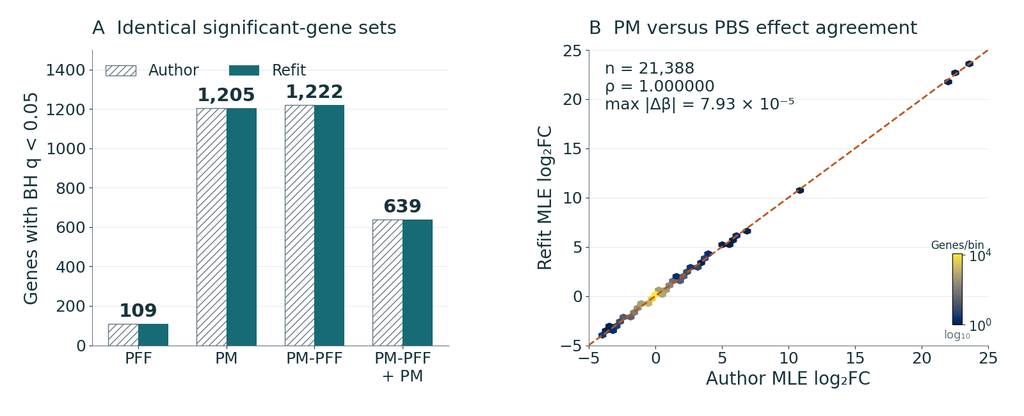

Matching bars recover 109 / 1,205 / 1,222 / 639 significant genes in the four author-aligned contrasts. The effect comparison lies on the identity line. Every significant-set Jaccard equals 1, confirming numerical recovery at the deposited-count level. The same source animals are reused, so this agreement does not add independent biological replication.

Analysis: this project[Zhang et al., Science 2025](https://doi.org/10.1126/science.adu4132)

## Reproducible output retains a source-quality question

03 / Author reproduction

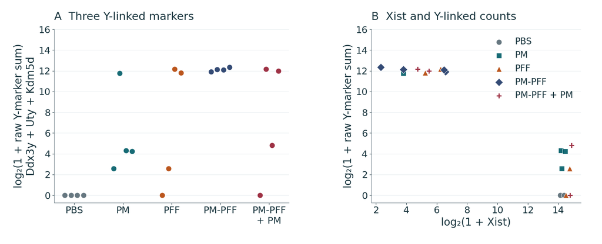

Points retain all 20 source animals. All four PBS controls have zero raw Ddx3y, Uty and Kdm5d counts, whereas other treatment groups vary. The Xist comparison provides another descriptive marker view. These patterns motivate checking source sex and sample identity, without assigning sex or proving confounding from expression alone.

Analysis: this project[Zhang et al., Science 2025](https://doi.org/10.1126/science.adu4132)

## Hypothalamus comparison remains method-sensitive

03 / Author reproduction

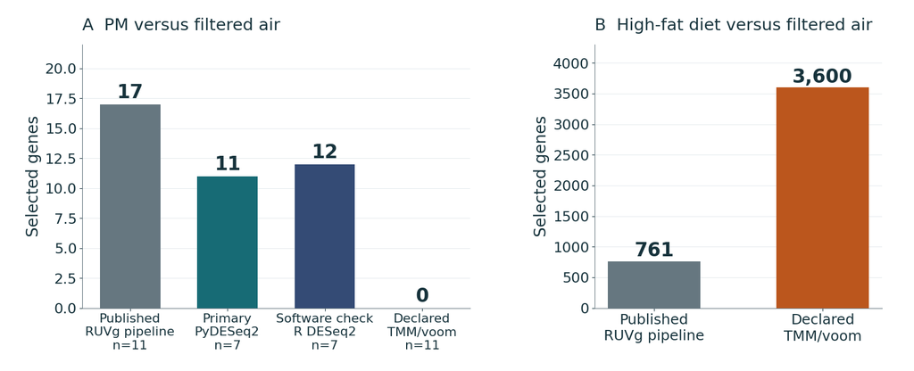

The original lists contain 17 PM and 761 HFD genes. The declared TMM/voom sensitivity returns 0 and 3,600 under different specified gates. The primary seven-animal analysis and its R implementation check are shown separately. Missing RUVg specifications prevent exact reconstruction, so these counts describe methodological sensitivity rather than biological nonreplication.

Analysis: this project[Rajagopalan et al., JCI 2020](https://doi.org/10.1172/JCI137315)

## miR-574-5p direction agrees but BH confirmation does not

03 / Author reproduction

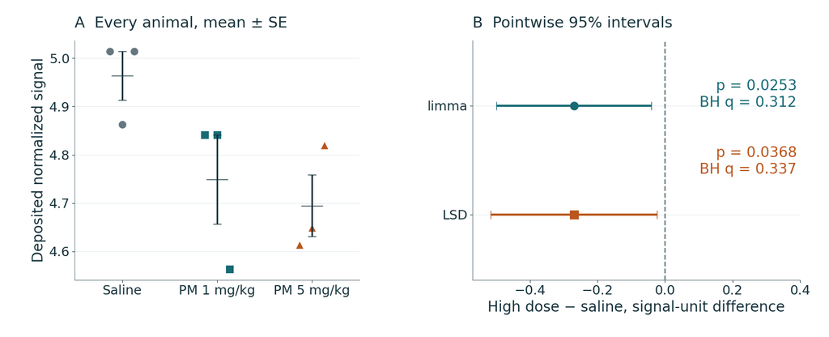

Animal points show lower miR-574-5p signal at high dose. Its estimated difference is −0.26945 deposited signal units. The nominal limma interval excludes zero, but p = 0.0253 becomes BH q = 0.312 across the array. ANOVA p = 0.0788 also prevents protected LSD. Directional agreement therefore exceeds the supported multiplicity-adjusted claim.

Analysis: this project[Ku et al., Part. Fibre Toxicol. 2017](https://doi.org/10.1186/s12989-017-0215-3) · [Ritchie et al., NAR 2015](https://doi.org/10.1093/nar/gkv007)

## Ozone genotype effects show conditional concordance

03 / Author reproduction

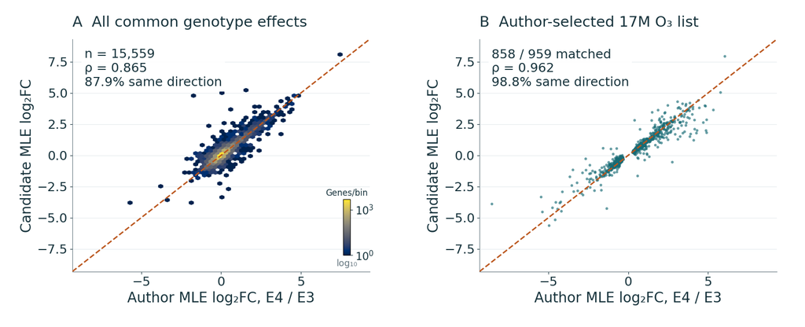

The deposited genotype threshold recovers 2,501 genes exactly. Across common finite effects, correlation is ρ = 0.865. The author-selected S3 subset gives ρ = 0.962 and 98.8% directional agreement among matched effects. Because the subset was selected and the source animals are reused, its stronger agreement cannot establish unbiased transcriptome-wide replication.

Analysis: this project[Nakamya et al., IJMS 2025](https://doi.org/10.3390/ijms26062407)

## Reproduction conclusions differ across studies

03 / Author reproduction

| Study | Defensible result | Remaining limit |
| --- | --- | --- |
| Cortex | Exact four significant-gene sets and code PCA | Read-level pipeline and source sex/identity unresolved |
| Hypothalamus | Declared TMM/voom sensitivity | RUVg controls and k unavailable |
| miRNA | Target direction and unprotected nominal agreement | Omnibus gate and array-wide BH do not confirm target |
| Ozone | Exact deposited threshold selection and matched effects | Different quantifier and selected-list conditioning |

Scientific references[Rajagopalan et al., JCI 2020](https://doi.org/10.1172/JCI137315) · [Zhang et al., Science 2025](https://doi.org/10.1126/science.adu4132) · [Nakamya et al., IJMS 2025](https://doi.org/10.3390/ijms26062407)

## New analyses within this project

04 / Project results

Primary reanalysis, response heterogeneity, gene sets and spatial-reference modeling

## Primary HY analysis identifies 11 BH discoveries

04 / Project results

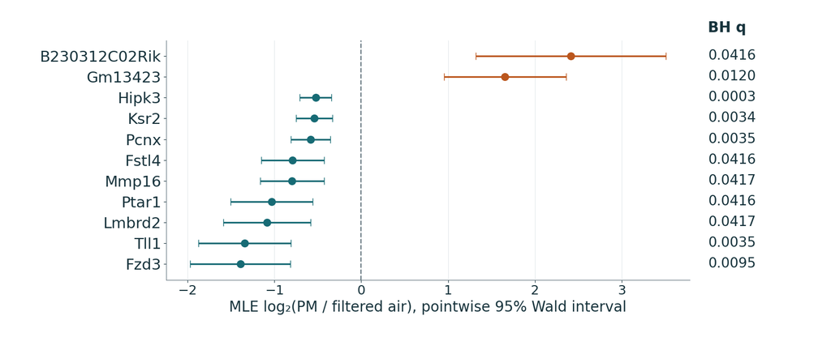

For 4 filtered-air and 3 PM animals, the primary model identifies 11 BH discoveries: two higher and nine lower. Points show MLE log₂ fold changes, and bars are pointwise Wald 95% intervals. Direction indicates the regional contrast. These intervals are neither simultaneous confidence bands nor evidence that each spatial cell changes similarly.

Analysis: this project[Rajagopalan et al., JCI 2020](https://doi.org/10.1172/JCI137315)

## Primary cortex analysis uses eight PM/PBS animals

04 / Project results

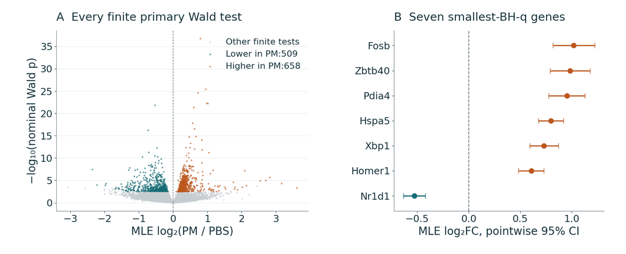

The volcano separates effect magnitude from nominal Wald evidence, while colors identify BH discoveries. The seven smallest-q genes have pointwise MLE intervals. The eight-animal primary comparison yields 1,167 discoveries, 658 higher and 509 lower. Its population and model differ from the 20-animal reconstruction that recovered 1,205 PM genes.

Analysis: this project[Zhang et al., Science 2025](https://doi.org/10.1126/science.adu4132)

## New miRNA analysis retains the full test family

04 / Project results

1 / 0

BH discoveries at low / high dose

| Contrast | Tested features | BH discoveries | Effect scale |
| --- | --- | --- | --- |
| PM 1 mg/kg versus control | 1,245 | 1 higher | Original signal difference |
| PM 5 mg/kg versus control | 1,245 | 0 | Original signal difference |
| Separate omnibus F | 1,245 | 1 | Joint condition difference |

The low-dose discovery is mmu-miR-5119. Lower detection flags remain visible, and no array is removed.

Analysis: this project[Ku et al., Part. Fibre Toxicol. 2017](https://doi.org/10.1186/s12989-017-0215-3) · [Ritchie et al., NAR 2015](https://doi.org/10.1093/nar/gkv007)

## Ozone discovery counts depend on stratum and test

04 / Project results

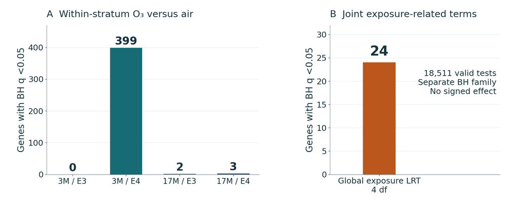

Separate within-stratum BH procedures yield 0 / 399 / 2 / 3 genes in starting-age/APOE order 3M/E3, 3M/E4, 17M/E3 and 17M/E4. The joint 4-df exposure LRT finds 24 genes in another testing family. Unequal discovery counts reflect evidence and precision together, and cannot by themselves establish an interaction.

Analysis: this project[Nakamya et al., IJMS 2025](https://doi.org/10.3390/ijms26062407)

## Age-dependent exposure has the clearest joint signal

04 / Project results

08

age-dependent response genes; 1 under pooled BH

| Secondary joint LRT | df | Within-family BH hits | Across-three-family BH hits |
| --- | --- | --- | --- |
| Genotype-dependent exposure | 2 | 0 | 0 |
| Age-dependent exposure | 2 | 8 | 1 |
| Three-way interaction | 1 | 0 | 0 |

Age-response genes: Ryr3, Rps24, Pkig, Rpl26, Inpp5d, Stk11, Rpl34 and Gm21586.

Analysis: this project[Nakamya et al., IJMS 2025](https://doi.org/10.3390/ijms26062407) · [Love et al., Genome Biol. 2014](https://doi.org/10.1186/s13059-014-0550-8)

## Animal-level profiles contextualize response differences

04 / Project results

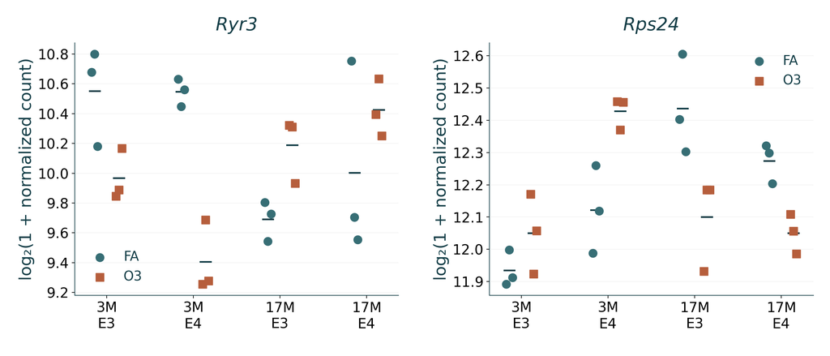

Each gene retains all 24 sequenced animals, grouped by starting age, APOE and exposure. Points show log₂(1 + normalized count), and short segments give descriptive means. Ryr3 and Rps24 belong to the eight age-dependent LRT discoveries. Fixed horizontal offsets only separate symbols, while the factorial model supplies the interaction test.

Analysis: this project[Nakamya et al., IJMS 2025](https://doi.org/10.3390/ijms26062407)

## ORA and ranked GSEA describe different evidence

04 / Project results

| Contrast | ORA up / down terms | GSEA algorithmic-FDR terms |
| --- | --- | --- |
| HY | 0 / 0 | 916 |
| ACA | 86 / 2 | 223 |
| O₃ M3_E3 | 0 / 0 | 4 |
| O₃ M3_E4 | 0 / 0 | 368 |
| O₃ M17_E3 | 0 / 0 | 85 |
| O₃ M17_E4 | 0 / 0 | 23 |

These correlated terms are not counts of independent biological mechanisms.

Analysis: this project[Subramanian et al., PNAS 2005](https://doi.org/10.1073/pnas.0506580102) · [Gene Ontology Consortium](https://geneontology.org/docs/go-enrichment-analysis/)

## Selected GO patterns across the six RNA contrasts

04 / Project results

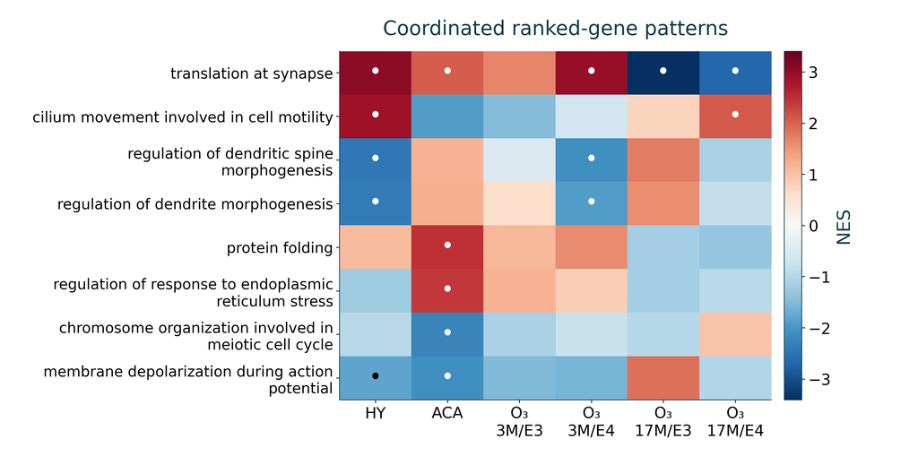

Color gives the signed normalized enrichment score on a common scale, and dots mark algorithmic GSEA FDR < 0.05. Gray cells are ineligible or unavailable. These are the first eight terms of a fixed 22-term display selection. Correlated annotations and selected display terms prevent reading the matrix as independent mechanisms or exhaustive pathway activity.

Analysis: this project[Subramanian et al., PNAS 2005](https://doi.org/10.1073/pnas.0506580102) · [Gene Ontology Consortium](https://geneontology.org/docs/go-enrichment-analysis/)

## Gene products add biological context without measuring protein

04 / Project results

| Gene | Annotated product / role | Measured panel |
| --- | --- | --- |
| [Tll1](https://www.ncbi.nlm.nih.gov/gene/21892) | Tolloid-like extracellular processing protease | Yes |
| [Fosb](https://www.ncbi.nlm.nih.gov/gene/14282) | FosB, AP-1 transcription-factor subunit | Yes |
| [S1pr1](https://www.ncbi.nlm.nih.gov/gene/13609) | Sphingosine-1-phosphate receptor | Yes |
| [Hspa5](https://www.ncbi.nlm.nih.gov/gene/14828) | BiP/GRP78 endoplasmic-reticulum chaperone | No |
| [Ksr2](https://www.ncbi.nlm.nih.gov/gene/333050) | RAF–MEK/MAPK scaffold | No |
| [C730002L08Rik](https://www.ncbi.nlm.nih.gov/gene/320155) | Noncoding RNA, no annotated protein | Yes |

Analysis: this project[NCBI Gene: Tll1](https://www.ncbi.nlm.nih.gov/gene/21892) · [UniProtKB: Tll1](https://www.uniprot.org/uniprotkb/Q62381/entry) · [Zhang et al., Nature 2023](https://doi.org/10.1038/s41586-023-06808-9)

## Measured cortical layers organize the reference cells

04 / Project results

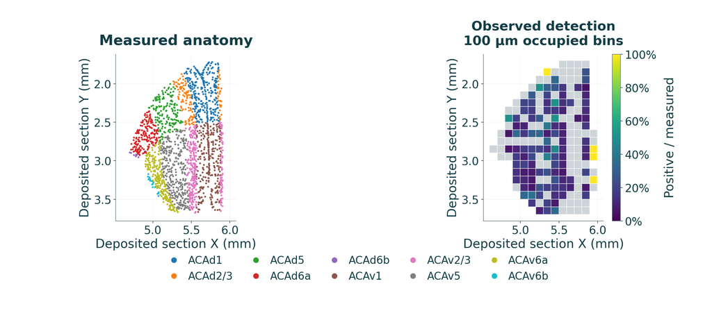

The largest ACA section contains 1,940 measured cells. Left, deposited positions and anatomical labels reveal cortical layers. Right, each occupied 100-µm bin shows measured Fosb-positive cells divided by all measured cells, including zeros. Empty bins remain unobserved. The pattern describes one unexposed donor and does not estimate a layer-specific PM effect.

Analysis: this project[Zhang et al., Nature 2023](https://doi.org/10.1038/s41586-023-06808-9)

## Measured hypothalamic nuclei and Tll1 detection

04 / Project results

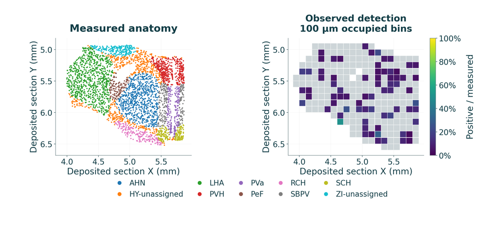

The largest HY section contains 3,565 measured cells. Anatomical labels organize the deposited cell positions, and occupied bins display positive/all-cell detection. Across the complete reference HY, Tll1 is detected in 667 of 37,811 cells, or 1.764%. Sparse detection can reflect biology and assay sensitivity, without resolving either explanation from these data alone.

Analysis: this project[Zhang et al., Nature 2023](https://doi.org/10.1038/s41586-023-06808-9)

## Illustrative regional scaling preserves the measured geometry

04 / Project results

**ACA / Fosb:** the shrunken bulk effect gives an approximately twofold scenario.

**HY / Tll1:** the shrunken bulk effect gives a 0.428-fold scenario.

- Every positive reference value receives the same regional multiplier for its gene.
- Measured zeros stay zero, and positions and cell counts stay fixed.
- The interface links measured candidates, gene products, source animal results and uncertainty targets.

[Open the paired 3D cortical viewer](https://amarusimonaguerojimenez.github.io/Air-Pollution-Brain-Omics-Mouse/cortex_viewer.html).

Analysis: this project[Zhang et al., Nature 2023](https://doi.org/10.1038/s41586-023-06808-9)

## Hypothalamus: interactive reference and PM₂.₅ scenario

04 / Project results

Loading interactive map…

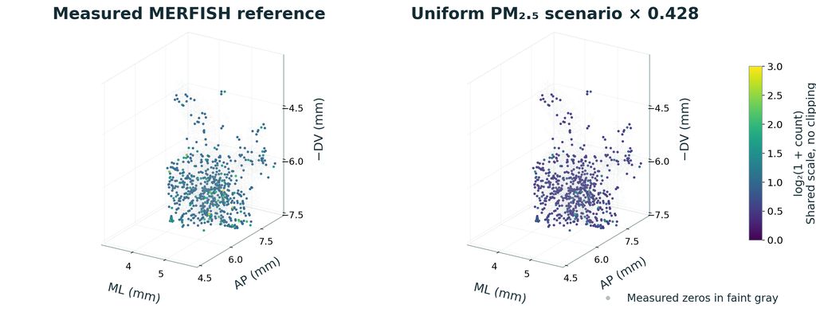

Left shows measured Tll1 counts. Right multiplies every value by 0.42808, carrying the regional shrunken effect into an illustrative scenario. Both panels retain 37,811 positions and the same 667 positive cells. A common color scale reveals the magnitude change. The display does not identify cell-specific exposure responses or infer cell loss.

[interactive chart not shown]

Drag either map to rotate both scenes. Choose a measured gene and apply it. The panels retain the same registered cells. PM₂.₅ applies one regional multiplier, without identifying cell-specific exposure responses.

Analysis: this project[Rajagopalan et al., JCI 2020](https://doi.org/10.1172/JCI137315) · [Zhang et al., Nature 2023](https://doi.org/10.1038/s41586-023-06808-9)

## Cortex: interactive reference and PM₂.₅ scenario

04 / Project results

Loading interactive map…

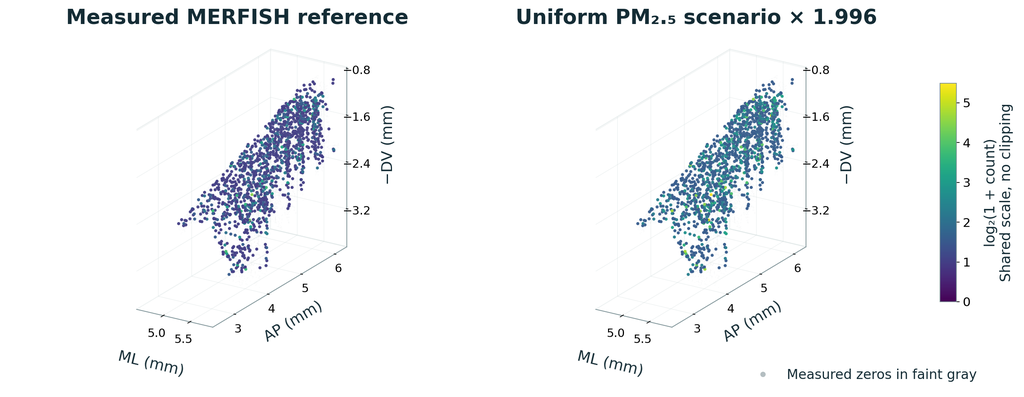

Left shows measured Fosb counts. Right applies the regional 1.996-fold multiplier to the same reference. The 14,582 positions and 1,418 positive cells remain fixed, with a shared full color scale. The brighter scenario illustrates a bulk effect. It does not establish which cortical layers or cell types respond to PM₂.₅.

[interactive chart not shown]

Drag either map to rotate both scenes. Choose a measured gene and apply it. The panels retain the same registered cells. PM₂.₅ applies one regional multiplier, without identifying cell-specific exposure responses.

Analysis: this project[Zhang et al., Science 2025](https://doi.org/10.1126/science.adu4132) · [Zhang et al., Nature 2023](https://doi.org/10.1038/s41586-023-06808-9)

## Spatial Gaussian regression rarely improves the baseline

04 / Project results

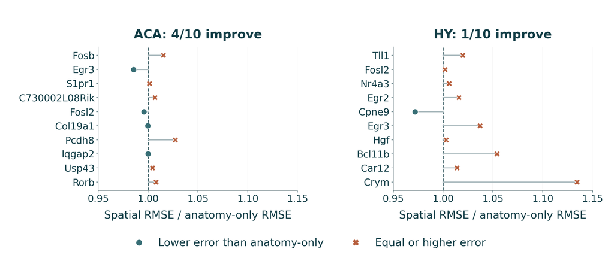

Each point compares spatial-model RMSE with anatomy-only RMSE on identical held-out sections. A ratio below 1 favors the spatial model, which improves 4/10 ACA genes and 1/10 HY genes. Added coordinates and basis functions therefore provide limited benefit here. A smooth full-reference map alone would not reveal this prediction failure.

Analysis: this project[Zhang et al., Nature 2023](https://doi.org/10.1038/s41586-023-06808-9) · [Murphy, 2007, Gaussian conjugacy](https://www.cs.ubc.ca/~murphyk/Papers/bayesGauss.pdf)

## Overall coverage hides important Gaussian limitations

04 / Project results

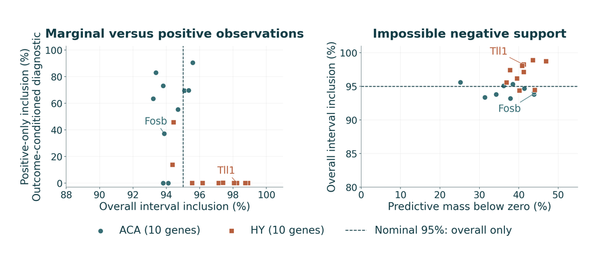

Left, overall interval inclusion can be high while inclusion among positive observations is poor. Positive-only inclusion is a conditional diagnostic, without a nominal 95% target. Right, the Gaussian predictive distribution assigns mass below zero on log(1 + count), an impossible range. Together these checks expose limitations hidden by marginal coverage alone.

Analysis: this project[Zhang et al., Nature 2023](https://doi.org/10.1038/s41586-023-06808-9) · [Murphy, 2007, Gaussian conjugacy](https://www.cs.ubc.ca/~murphyk/Papers/bayesGauss.pdf)

## Bounded detection improves modestly in ACA but fails in HY

04 / Project results

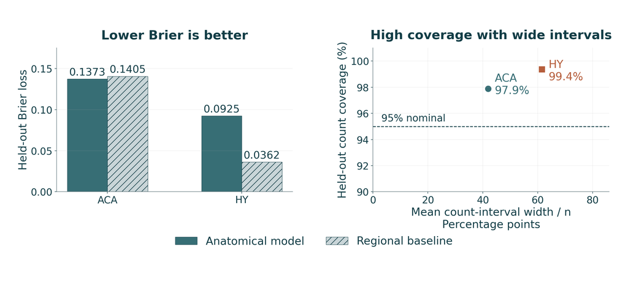

Lower Brier loss favors the model. ACA improves modestly, 0.13725 versus 0.14051, while HY worsens, 0.09246 versus 0.03621. The coverage–width plot shows that high predictive count coverage accompanies wide intervals. These held-out comparisons retain prior-only anatomical groups, so bounded probabilities alone do not establish accurate or transferable prediction.

Analysis: this project[Zhang et al., Nature 2023](https://doi.org/10.1038/s41586-023-06808-9) · [SciPy, beta-binomial distribution](https://docs.scipy.org/doc/scipy/reference/generated/scipy.stats.betabinom.html)

## Prediction quality depends on error, coverage and support

04 / Project results

**Prediction error.** The bounded model has slightly lower Brier loss than the regional baseline in ACA. In HY, its full evaluation is worse than the baseline.

**Training support.** In each HY gene evaluation, 79 of 186 reserved section–anatomy groups contain anatomical labels unavailable in training. Their predictions depend only on the stated prior and remain in the score.

**Uncertainty.** Wide intervals can cover many outcomes while providing little precision. Bounded probabilities, stable numerical integration and visually plausible maps do not by themselves demonstrate useful prediction or higher spatial resolution.

Analysis: this project[Zhang et al., Nature 2023](https://doi.org/10.1038/s41586-023-06808-9) · [Murphy, 2007, Gaussian conjugacy](https://www.cs.ubc.ca/~murphyk/Papers/bayesGauss.pdf) · [SciPy, beta-binomial distribution](https://docs.scipy.org/doc/scipy/reference/generated/scipy.stats.betabinom.html)

## ACA posterior detection separates uncertainty targets

04 / Project results

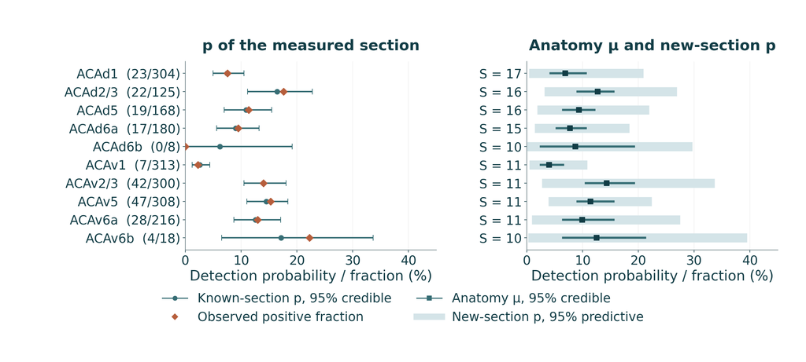

For Fosb, the left panel compares observed fractions with known-section posterior probabilities. The right panel separates anatomy-mean credible intervals from new-section propensity predictions. The pale interval expresses section-to-section uncertainty, and its target differs from the dark hypermean interval. These full-reference estimates describe the unexposed donor, while held-out performance is evaluated separately.

Analysis: this project[Zhang et al., Nature 2023](https://doi.org/10.1038/s41586-023-06808-9) · [SciPy, beta-binomial distribution](https://docs.scipy.org/doc/scipy/reference/generated/scipy.stats.betabinom.html)

## HY fitted anatomy does not guarantee held-out prediction

04 / Project results

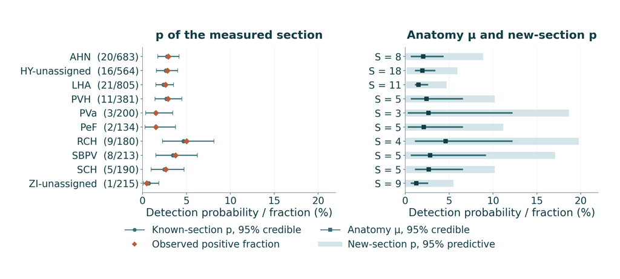

For Tll1, fitted section probabilities remain within 0–1 despite sparse detections. The anatomy mean and new-section propensity carry different uncertainty. A fitted map can still look plausible when held-out anatomical labels lack training support. The full HY evaluation retains those groups, making the resulting prior dependence visible in the reported prediction error.

Analysis: this project[Zhang et al., Nature 2023](https://doi.org/10.1038/s41586-023-06808-9) · [SciPy, beta-binomial distribution](https://docs.scipy.org/doc/scipy/reference/generated/scipy.stats.betabinom.html)

## Numerical stability and predictive usefulness are separate

04 / Project results

| 64×48 versus 96×64 grid | ACA | HY |
| --- | --- | --- |
| Maximum mean μ change | 0.000192 | 0.000537 |
| Maximum μ interval endpoint change | 0.0203 | 0.0181 |
| Maximum new-section p endpoint change | 0.00254 | 0.00358 |
| Held-out count coverage | 97.89% → 98.05% | 99.35% unchanged |

Finite-grid and seeded simulation checks support computational review. They do not repair weak prediction or validate the priors biologically.

Analysis: this project[Zhang et al., Nature 2023](https://doi.org/10.1038/s41586-023-06808-9) · [Murphy, 2007, Gaussian conjugacy](https://www.cs.ubc.ca/~murphyk/Papers/bayesGauss.pdf) · [SciPy, beta-binomial distribution](https://docs.scipy.org/doc/scipy/reference/generated/scipy.stats.betabinom.html)

## Limits that change the scientific interpretation

05 / Interpretation

| Evidence layer | Supported inference | Boundary |
| --- | --- | --- |
| Author reproduction | Numerical recovery using source data | No new biological replicates |
| Bulk / miRNA contrasts | Study-specific regional associations | Composition, small n and source metadata |
| GO and response interactions | Exploratory coordinated patterns / defined contrasts | Multiplicity, correlated terms, model assumptions |
| Measured atlas | Detection at original cell positions | One donor, targeted panel, section gaps |
| Spatial Bayesian models | Conditional reference estimates and held-out diagnostics | Limited baseline gain, prior support, model misspecification |
| PM₂.₅ scenario | Uniform group-effect illustration | No identified cellular exposure response |

Scientific references[Rajagopalan et al., JCI 2020](https://doi.org/10.1172/JCI137315) · [Zhang et al., Science 2025](https://doi.org/10.1126/science.adu4132) · [Nakamya et al., IJMS 2025](https://doi.org/10.3390/ijms26062407)

## Conclusions supported by the completed work

05 / Interpretation

04

conclusions supported by the evidence

1. Cortex author-aligned reconstruction recovers all four significant-gene sets, alongside an unresolved source-quality signal.
2. New reanalyses expose model, testing-family and small-sample sensitivity. Age-dependent ozone response receives the clearest joint interaction signal.
3. Measured sections, gene products and bounded detection models improve interpretation of the reference atlas.
4. Spatial validation reports limited prediction gains and model failures openly. The work does not establish an exposed cellular brain reconstruction.

Scientific references[Rajagopalan et al., JCI 2020](https://doi.org/10.1172/JCI137315) · [Zhang et al., Science 2025](https://doi.org/10.1126/science.adu4132) · [Nakamya et al., IJMS 2025](https://doi.org/10.3390/ijms26062407)

## Future work requires independent biological information

05 / Interpretation

NEXT

independent biological validation

- Recover source sex/identity metadata and missing author RUVg specifications.
- Validate bulk candidates in independent animals and matched cell populations.
- Evaluate sparse-count or hurdle models and cross-donor spatial prediction.
- Acquire pollutant-exposed spatial/single-cell measurements before inferring cell-specific responses.
- Explore UCSC Genome Browser, Ensembl and ENCODE for compatible brain epigenomic evidence.

## Reproducibility and discussion

05 / Interpretation

**Complete evidence:** source mappings, analytical populations, model code, frozen references, tables and bilingual figures.

**Presentation controls:** arrow keys navigate, Esc opens overview, Notes opens the detailed explanation, and the language switch keeps the same slide.

[Scientific report](https://amarusimonaguerojimenez.github.io/Air-Pollution-Brain-Omics-Mouse/) · [Repository](https://github.com/AmaruSimonAgueroJimenez/Air-Pollution-Brain-Omics-Mouse)

The following appendix contains protocols, formulas, sensitivity checks, candidate lists and references.

## Technical appendix

06 / Technical appendix

Protocols, testing families, prior definitions and reproducibility

## PM₂.₅ exposure protocols remain distinct

06 / Technical appendix

| Arm | Starting context | Protocol | Timing caution |
| --- | --- | --- | --- |
| HY / GSE145840 | Male C57BL/6J, 3 weeks | About 60–120 µg/m³, mean 80; 6 h/day, 5 days/week, 14 weeks | Terminal age/harvest lag not independently reported |
| ACA / GSE297423 | hWT αSyn, 2 months, sex unreported | 2 µL of 5 mg/mL PM intranasal, every 2 days for 2 months | Separate from older conventional-mouse arm |
| miRNA / GSE93967 | Male C57BL/6, about 8 weeks | 1 or 5 mg/kg oropharyngeal aspiration, every other day for 4 weeks | Harvest 18 h after final dose |

Scientific references[Rajagopalan et al., JCI 2020](https://doi.org/10.1172/JCI137315) · [Zhang et al., Science 2025](https://doi.org/10.1126/science.adu4132) · [Ku et al., Part. Fibre Toxicol. 2017](https://doi.org/10.1186/s12989-017-0215-3)

## Ozone protocol and sequenced sample size

06 / Technical appendix

- Male human APOE3/APOE4 targeted-replacement mice.
- Start exposure at 3 or 17 months.
- **0.8 ppm O₃, 7 h/day for five days**, followed by nine days of filtered air.
- Repeat eight cycles. Left hippocampus enters RNA-seq.
- Paper-wide 14–16 animals per group differs from **three sequenced animals per stratum**.
- One SDRF strain string differs for Sample1 / ERR14708304.

Scientific references[Nakamya et al., IJMS 2025](https://doi.org/10.3390/ijms26062407)

## Median-of-ratios normalization and length offsets

06 / Technical appendix

$$G_g=\left(\prod_i K_{gi}\right)^{1/m},\qquad
s_i=\operatorname{median}_{g}\left(\frac{K_{gi}}{G_g}\right)$$

For count genes with a usable geometric mean:

Normalized PM counts are $K_{gi}/s_i$. Size factors use the retained analysis universe.

Ozone uses sample/gene effective-length normalization through tximport. TPM is not substituted as negative-binomial input.

VST/PCA and row-standardized heatmaps are descriptive transforms, separate from the count likelihood.

Scientific references[Love et al., Genome Biol. 2014](https://doi.org/10.1186/s13059-014-0550-8) · [Soneson et al. 2015](https://doi.org/10.12688/f1000research.7563.2) · [Rajagopalan et al., JCI 2020](https://doi.org/10.1172/JCI137315)

## Empirical-Bayes moderation in limma

06 / Technical appendix

$$s_{f,\mathrm{post}}^2=
\frac{d_0s_{0f}^2+d_fs_f^2}{d_0+d_f}$$

$$t_{f,\mathrm{mod}}=
\frac{\widehat\Delta_f}{s_{f,\mathrm{post}}\sqrt{v_f}}$$

The prior variance trend depends on signal level. Moderation borrows information across features.

Pointwise moderated t intervals and BH across features answer different questions.

No verified pairing or batch variable is invented for the nine arrays.

Scientific references[Ritchie et al., NAR 2015](https://doi.org/10.1093/nar/gkv007) · [Ku et al., Part. Fibre Toxicol. 2017](https://doi.org/10.1186/s12989-017-0215-3)

## Multiplicity families and non-nested discovery lists

06 / Technical appendix

| Example | Family | BH discoveries |
| --- | --- | --- |
| O₃ stratum tests | Each stratum separately | 0 / 399 / 2 / 3 |
| O₃ stratum tests | All four valid p-value families | 1 / 43 / 4 / 6 |
| Age-dependent exposure LRT | Its own gene family | 8 |
| Three secondary LRTs | All valid tests pooled | 1 age-response hit |

Pooled BH adjusts a different p-value collection. Neither list is selected to maximize discoveries.

Scientific references[Nakamya et al., IJMS 2025](https://doi.org/10.3390/ijms26062407) · [Love et al., Genome Biol. 2014](https://doi.org/10.1186/s13059-014-0550-8)

## Software and leave-one-animal-out sensitivity

06 / Technical appendix

| HY check | Saved result |
| --- | --- |
| PyDESeq2 versus R BH hits | 11 versus 12 |
| Effect Pearson correlation | 0.9999999996 |
| Cook status agreement | All 19,611 retained genes |
| Discordant BH threshold gene | Tnrc6c: Python 0.05211, R 0.03992 |
| Leave-one-out BH hit range | 0–825 |
| Direction of 11 primary hits | Preserved in all seven omissions |

Scientific references[Love et al., Genome Biol. 2014](https://doi.org/10.1186/s13059-014-0550-8) · [Muzellec et al. 2023](https://doi.org/10.1093/bioinformatics/btad547) · [Rajagopalan et al., JCI 2020](https://doi.org/10.1172/JCI137315)

## Hypothalamic measured candidates

06 / Technical appendix

| Gene | Primary q | MLE log₂FC | Shrunken log₂FC | Evidence |
| --- | --- | --- | --- | --- |
| Tll1 | 0.0035 | -1.344 | -1.224 | q<.05 |
| Fosl2 | 0.0574 | -1.343 | -1.149 | q≥.05 |
| Nr4a3 | 0.0574 | -1.451 | -1.246 | q≥.05 |
| Egr2 | 0.0766 | -3.943 | -0.024 | q≥.05 |
| Cpne9 | 0.0793 | +2.253 | +1.915 | q≥.05 |
| Egr3 | 0.0793 | -4.238 | -0.020 | q≥.05 |
| Hgf | 0.106 | -3.455 | -0.027 | q≥.05 |
| Bcl11b | 0.111 | -3.601 | -0.023 | q≥.05 |
| Car12 | 0.111 | -3.652 | -0.023 | q≥.05 |
| Crym | 0.111 | -3.629 | -0.023 | q≥.05 |

Only Tll1 is primary-BH significant in HY; nine displayed candidates remain exploratory.

## Cortical measured candidates

06 / Technical appendix

| Gene | Primary q | MLE log₂FC | Shrunken log₂FC | Evidence |
| --- | --- | --- | --- | --- |
| Fosb | 2.27e-19 | +1.018 | +0.997 | q<.05 |
| Egr3 | 6.33e-14 | +0.629 | +0.611 | q<.05 |
| S1pr1 | 1.95e-07 | +0.539 | +0.512 | q<.05 |
| C730002L08Rik | 1.51e-06 | -0.630 | -0.594 | q<.05 |
| Fosl2 | 3.11e-06 | +0.542 | +0.509 | q<.05 |
| Col19a1 | 5.3e-06 | -0.494 | -0.463 | q<.05 |
| Pcdh8 | 7.43e-06 | +0.474 | +0.444 | q<.05 |
| Iqgap2 | 1.79e-05 | +0.440 | +0.410 | q<.05 |
| Usp43 | 3.09e-05 | -0.867 | -0.800 | q<.05 |
| Rorb | 3.36e-05 | -0.418 | -0.388 | q<.05 |

All ten displayed ACA candidates satisfy the primary regional BH threshold.

## Gaussian assumptions and prespecified sensitivity

06 / Technical appendix

| Component | Primary specification | Sensitivity / limitation |
| --- | --- | --- |
| Residual | Normal, variance σ² | Sparse nonnegative response may violate support |
| Section effect | Normal, variance 0.25σ² | New section contributes 0.25σ² |
| RBF lengths AP/DV/ML | 0.60 / 0.45 / 0.45 mm | Multiply all by 0.5 or 2 |
| Spatial prior variances | Fixed diagonal entries | Multiply by 0.25 or 4 |
| Unknown anatomy | Prior mean 0, extra variance 1×σ² | Report unavailable training anatomy |
| Validation | 5 guarded whole-section blocks | Within one donor only |

Scientific references[Zhang et al., Nature 2023](https://doi.org/10.1038/s41586-023-06808-9) · [Murphy, 2007, Gaussian conjugacy](https://www.cs.ubc.ca/~murphyk/Papers/bayesGauss.pdf) · [Rasmussen & Williams, 2006, ch. 2](https://gaussianprocess.org/gpml/chapters/RW2.pdf)

## Beta-binomial likelihood and new-section prediction

06 / Technical appendix

$$P(Y=y\mid n,\mu,\kappa)=\binom ny
\frac{B(y+\mu\kappa,n-y+(1-\mu)\kappa)}
{B(\mu\kappa,(1-\mu)\kappa)}$$

$$\rho=\frac1{\kappa+1}$$

$$p_s\mid y,n,\mu,\kappa\sim
\operatorname{Beta}(\mu\kappa+y,(1-\mu)\kappa+n-y).$$

Known-section components update to

Hyperposterior-weighted mixtures preserve parameter uncertainty.

Scientific references[Zhang et al., Nature 2023](https://doi.org/10.1038/s41586-023-06808-9) · [SciPy, beta-binomial distribution](https://docs.scipy.org/doc/scipy/reference/generated/scipy.stats.betabinom.html)

## Marginal coverage and outcome-conditioned diagnostics

06 / Technical appendix

$$P\{Y_*\in I_{0.95}(X_*,D)\}\approx0.95.$$

$$P\{Y_*\in I_{0.95}(X_*,D)\mid Y_*>0\}=0.95.$$

A nominal prediction interval targets a marginal statement:

It does not impose

Positive-only inclusion is a descriptive tail-recovery diagnostic.

Impossible negative predictive support is a separate likelihood limitation.

Scientific references[Zhang et al., Nature 2023](https://doi.org/10.1038/s41586-023-06808-9) · [Murphy, 2007, Gaussian conjugacy](https://www.cs.ubc.ca/~murphyk/Papers/bayesGauss.pdf) · [SciPy, beta-binomial distribution](https://docs.scipy.org/doc/scipy/reference/generated/scipy.stats.betabinom.html)

## Data and analyses outside the completed scope

06 / Technical appendix

- NO₂ brain papers remain in the literature inventory, without a complete expression matrix entering these four models.
- No exposed spatial or single-cell brain dataset is synthesized as measured evidence.
- Genes outside the targeted MERFISH panel remain unmeasured.
- UCSC, Ensembl and ENCODE epigenomic integration remains proposed future work.
- Independent cross-donor and exposure validation remains outstanding.

## Primary studies and spatial reference

06 / Technical appendix

**Rajagopalan et al. (2020).** Metabolic effects of air pollution exposure and reversibility. J Clin Invest. [doi:10.1172/JCI137315](https://doi.org/10.1172/JCI137315)

**Zhang et al. (2025).** Lewy body dementia promotion by air pollutants. Science. [doi:10.1126/science.adu4132](https://doi.org/10.1126/science.adu4132)

**Ku et al. (2017).** NF-κB-regulated microRNA-574-5p underlies synaptic and cognitive impairment in response to atmospheric PM₂.₅ aspiration. Particle and Fibre Toxicology. [doi:10.1186/s12989-017-0215-3](https://doi.org/10.1186/s12989-017-0215-3)

**Nakamya et al. (2025).** Age- and ApoE Genotype-Dependent Transcriptomic Responses to O₃ in the Hippocampus of Mice. Int J Mol Sci. [doi:10.3390/ijms26062407](https://doi.org/10.3390/ijms26062407)

**Zhang et al. (2023).** Molecularly defined and spatially resolved cell atlas of the whole mouse brain. Nature. [doi:10.1038/s41586-023-06808-9](https://doi.org/10.1038/s41586-023-06808-9)

## Statistical software references

06 / Technical appendix

**DESeq2:** Love et al. 2014. 10.1186/s13059-014-0550-8

**PyDESeq2:** Muzellec et al. 2023. 10.1093/bioinformatics/btad547

**limma:** Ritchie et al. 2015. 10.1093/nar/gkv007

**Salmon:** Patro et al. 2017. 10.1038/nmeth.4197

**tximport:** Soneson et al. 2015. 10.12688/f1000research.7563.2

**apeglm:** Zhu et al. 2019. 10.1093/bioinformatics/bty895

## Bayesian derivation and implementation sources

06 / Technical appendix

- Fixed-basis Bayesian regression and prediction: [Rasmussen and Williams, chapter 2](https://gaussianprocess.org/gpml/chapters/RW2.pdf).
- Conjugate Gaussian analysis: [Murphy, technical note](https://www.cs.ubc.ca/~murphyk/Papers/bayesGauss.pdf).
- Beta-binomial distribution: [official SciPy documentation](https://docs.scipy.org/doc/scipy/reference/generated/scipy.stats.betabinom.html).
- Project formulas, priors and validation: frozen method files and source implementations.

The reference models are project implementations with explicitly evaluated assumptions.

Scientific references[Rasmussen & Williams, 2006, ch. 2](https://gaussianprocess.org/gpml/chapters/RW2.pdf) · [Murphy, 2007, Gaussian conjugacy](https://www.cs.ubc.ca/~murphyk/Papers/bayesGauss.pdf) · [SciPy, beta-binomial distribution](https://docs.scipy.org/doc/scipy/reference/generated/scipy.stats.betabinom.html)

## Rebuilding the presentation without refitting the science

06 / Technical appendix

The builder reads saved result tables and produces presentation-sized figures, paired QMD sources and HTML.

```
.venv-analysis/bin/python scripts/build_defense_slides.py --figures
.venv-analysis/bin/python scripts/render_docs.py --page defense.qmd
.venv-analysis/bin/python scripts/build_defense_slides.py --package
.venv-analysis/bin/python scripts/validate_defense_slides.py
```

Source hashes, equal EN/ES slide IDs, figure provenance and browser review accompany the deck.